# Demographics Stats - PhysioNet Sepsis Challenge

efg | 2019-04-06

> An expanded training database is now available, containing data from a total of 40,336 subjects. The complete training database (42 MB), consisting of two parts: training set A (20,336 subjects) and B (20,000 subjects).

# 1 Purpose

The purpose of this notebook is to take a preliminary look at the raw data from 40,336 patients in the PhysioNet 2019 challenge, where some had sepsis and some did not.

The focus of this notebook is on the Demographics data (columns 35-40 in the raw files):

| Quantity | Units | Description |
| --- | --- | --- |
| `Age` | Years |  |
| `Gender` |  | Female (0) or Male (1) |
| `Unit1` |  | Administrative identifier for ICU unit (MICU) |
| `Unit2` |  | Administrative identifier for ICU unit (SICU) |
| `HospAdmTime` | Hours | Time between hospital admit and ICU admit |
| `ICULOS` | Hours | ICU length-of-stay (hours since ICU admit) |

and the outcome (column 41), `SepsisLabel`.

For sepsis patients, `SepsisLabel` is 1 if $t \ge t_{sepsis} - 6$ and 0 if $t < t_{sepsis} - 6$.

For non-sepsis patients, `SepsisLabel` is 0.

# 2 Background

The data being analyzed is from the [Early Prediction of Sepsis from Clinical Data: the PhysioNet/Computing in Cardiology Challenge 2019](https://physionet.org/challenge/2019/).

# 3 Exploration

## 3.1 Setup

```r
plotCaptionLeft  <- "PhysioNet 2019 Sepsis Project"
plotCaptionRight <- paste("efg", format(Sys.time(), "%Y-%m-%d"))
```

```r
LOSbreaks <- c(1, 8, 12, 18, 24, 30, 36, 48,
                             60, 72, 96, 192, 336)
```

### 3.1.1 Packages

```r
library(tidyverse)
library(writexl)
library(kableExtra) # kable_styling
```

### 3.1.2 Helper function

```r
Show <- function(data, caption="", bigMark="", ...)
{
  data                                          %>%
  kable("html",
        caption=caption,
        format.args = list(big.mark=bigMark))   %>%
  kable_styling(bootstrap_options = c("striped", "bordered", "condensed"),
                position = "left", full_width = FALSE, ...)
}
```

### 3.1.3 Load PhysioNet 2019 Challenge Combined Data

```r
load(file = "../../data/PhysioNet-2019-Raw-Data-A.RData")
dim(allDataA)
```

```
[1] 790215     43
```

```r
load(file = "../../data/PhysioNet-2019-Raw-Data-B.RData")
dim(allDataB)
```

```
[1] 761995     43
```

Combine A and B

```r
allData <- bind_rows(allDataA, allDataB)
dim(allData)
```

```
## [1] 1552210      43
```

**Summary**

```r
allData                                      %>%
  group_by(Source)                           %>%
  summarize(nRecord  = n(),
            nPatient = n_distinct(patient))  %>%
  ungroup()                                  %>%
  Show(bigMark = ",")
```

| Source | nRecord | nPatient |
| --- | --- | --- |
| A | 790,215 | 20,336 |
| B | 761,995 | 20,000 |

```r
allData                                      %>%
  summarize(nSource  = n_distinct(Source),
            nRecord  = n(),
            nPatient = n_distinct(patient))  %>%
  Show(bigMark = ",")
```

| nSource | nRecord | nPatient |
| --- | --- | --- |
| 2 | 1,552,210 | 40,336 |

`patient` field is unique across both Souces.

Sample records

```r
allData    %>%
  head(50) %>%
  Show()   %>%
  scroll_box(width = "800px", height = "500px")
```

| Source | patient | ICULOS | HR | O2Sat | Temp | SBP | MAP | DBP | Resp | EtCO2 | BaseExcess | HCO3 | FiO2 | pH | PaCO2 | SaO2 | AST | BUN | Alkalinephos | Calcium | Chloride | Creatinine | Bilirubin_direct | Glucose | Lactate | Magnesium | Phosphate | Potassium | Bilirubin_total | … |
| --- | --- | --- | --- | --- | --- | --- | --- | --- | --- | --- | --- | --- | --- | --- | --- | --- | --- | --- | --- | --- | --- | --- | --- | --- | --- | --- | --- | --- | --- | --- |
| A | p000001 | 1 | NA | NA | NA | NA | NA | NA | NA | NA | NA | NA | NA | NA | NA | NA | NA | NA | NA | NA | NA | NA | NA | NA | NA | NA | NA | NA | NA | … |
| A | p000001 | 2 | 97.0 | 95.0 | NA | 98.0 | 75.33 | NA | 19.0 | NA | NA | NA | NA | NA | NA | NA | NA | NA | NA | NA | NA | NA | NA | NA | NA | NA | NA | NA | NA | … |
| A | p000001 | 3 | 89.0 | 99.0 | NA | 122.0 | 86.00 | NA | 22.0 | NA | NA | NA | NA | NA | NA | NA | NA | NA | NA | NA | NA | NA | NA | NA | NA | NA | NA | NA | NA | … |
| A | p000001 | 4 | 90.0 | 95.0 | NA | NA | NA | NA | 30.0 | NA | 24 | NA | NA | 7.36 | 100 | NA | NA | NA | NA | NA | NA | NA | NA | NA | NA | NA | NA | NA | NA | … |
| A | p000001 | 5 | 103.0 | 88.5 | NA | 122.0 | 91.33 | NA | 24.5 | NA | NA | NA | 0.28 | NA | NA | NA | NA | NA | NA | NA | NA | NA | NA | NA | NA | NA | NA | NA | NA | … |
| A | p000001 | 6 | 110.0 | 91.0 | NA | NA | NA | NA | 22.0 | NA | NA | NA | NA | NA | NA | NA | NA | NA | NA | NA | NA | NA | NA | NA | NA | NA | NA | NA | NA | … |
| A | p000001 | 7 | 108.0 | 92.0 | 36.11 | 123.0 | 77.00 | NA | 29.0 | NA | NA | NA | NA | NA | NA | NA | NA | NA | NA | NA | NA | NA | NA | NA | NA | NA | NA | NA | NA | … |
| A | p000001 | 8 | 106.0 | 90.5 | NA | 93.0 | 76.33 | NA | 29.0 | NA | NA | NA | NA | NA | NA | NA | NA | NA | NA | NA | NA | NA | NA | NA | NA | NA | NA | NA | NA | … |
| A | p000001 | 9 | 104.0 | 95.0 | NA | 133.0 | 88.33 | NA | 26.0 | NA | NA | NA | NA | NA | NA | NA | NA | NA | NA | NA | NA | NA | NA | NA | NA | NA | NA | NA | NA | … |
| A | p000001 | 10 | 102.0 | 91.0 | NA | 134.0 | 87.33 | NA | 30.0 | NA | NA | NA | NA | NA | NA | NA | NA | NA | NA | NA | NA | NA | NA | NA | NA | NA | NA | NA | NA | … |
| A | p000001 | 11 | 104.0 | 92.0 | 37.17 | 138.0 | 86.67 | NA | 19.0 | NA | 23 | NA | NA | 7.40 | 86 | 88 | NA | NA | NA | NA | NA | NA | NA | NA | NA | NA | NA | NA | NA | … |
| A | p000001 | 12 | NA | NA | NA | NA | NA | NA | NA | NA | NA | NA | NA | NA | NA | NA | NA | NA | NA | NA | NA | NA | NA | NA | NA | NA | NA | NA | NA | … |
| A | p000001 | 13 | 102.0 | 93.0 | NA | 129.0 | 77.00 | NA | 24.0 | NA | NA | NA | NA | NA | NA | NA | NA | NA | NA | NA | NA | NA | NA | NA | NA | NA | NA | NA | NA | … |
| A | p000001 | 14 | 108.0 | 90.0 | NA | 122.0 | 96.67 | NA | 27.0 | NA | NA | NA | NA | NA | NA | NA | NA | NA | NA | NA | NA | NA | NA | NA | NA | NA | NA | NA | NA | … |
| A | p000001 | 15 | 106.0 | 90.0 | NA | NA | NA | NA | 25.0 | NA | NA | NA | NA | NA | NA | NA | NA | NA | NA | NA | NA | NA | NA | NA | NA | NA | NA | NA | NA | … |
| A | p000001 | 16 | 109.0 | 91.0 | 36.56 | 132.0 | 96.67 | NA | 24.0 | NA | NA | NA | NA | NA | NA | NA | NA | NA | NA | NA | NA | NA | NA | NA | NA | NA | NA | NA | NA | … |
| A | p000001 | 17 | 103.0 | 90.0 | NA | NA | NA | NA | 30.0 | NA | 21 | 45 | NA | 7.37 | 90 | 91 | 16 | 14 | 98 | 9.3 | 85 | 0.7 | NA | 193 | NA | 2.0 | 3.3 | 3.8 | 0.3 | … |
| A | p000001 | 18 | 104.0 | 92.0 | NA | 132.0 | 81.33 | NA | 28.0 | NA | NA | NA | NA | NA | NA | NA | NA | NA | NA | NA | NA | NA | NA | NA | NA | NA | NA | NA | NA | … |
| A | p000001 | 19 | NA | NA | NA | NA | NA | NA | NA | NA | NA | NA | NA | NA | NA | NA | NA | NA | NA | NA | NA | NA | NA | NA | NA | NA | NA | NA | NA | … |
| A | p000001 | 20 | 109.0 | 91.0 | 37.11 | 147.0 | 91.00 | NA | 22.0 | NA | NA | NA | NA | NA | NA | NA | NA | NA | NA | NA | NA | NA | NA | NA | NA | NA | NA | NA | NA | … |
| A | p000001 | 21 | 113.0 | 90.0 | NA | NA | NA | NA | 17.0 | NA | NA | NA | NA | NA | NA | NA | NA | NA | NA | NA | NA | NA | NA | NA | NA | NA | NA | NA | NA | … |
| A | p000001 | 22 | 98.0 | 93.0 | NA | 134.0 | 83.33 | NA | 28.0 | NA | NA | NA | NA | NA | NA | NA | NA | NA | NA | NA | NA | NA | NA | NA | NA | NA | NA | NA | NA | … |
| A | p000001 | 23 | 100.0 | 85.0 | NA | NA | NA | NA | 29.0 | NA | NA | NA | NA | NA | NA | NA | NA | NA | NA | NA | NA | NA | NA | NA | NA | NA | NA | NA | NA | … |
| A | p000001 | 24 | 102.0 | 89.0 | 36.67 | 132.0 | 94.00 | NA | 32.0 | NA | 20 | NA | NA | 7.34 | 96 | 78 | NA | NA | NA | NA | NA | NA | NA | NA | NA | NA | NA | NA | NA | … |
| A | p000001 | 25 | 108.0 | 87.0 | NA | 149.0 | 89.67 | NA | 30.0 | NA | NA | NA | NA | NA | NA | NA | NA | NA | NA | NA | NA | NA | NA | NA | NA | NA | NA | NA | NA | … |
| A | p000001 | 26 | 107.0 | 90.0 | NA | 156.0 | 96.67 | NA | 26.0 | NA | NA | NA | NA | NA | NA | NA | NA | NA | NA | NA | NA | NA | NA | NA | NA | NA | NA | NA | NA | … |
| A | p000001 | 27 | 104.0 | 91.0 | NA | 168.0 | 141.33 | NA | 29.0 | NA | NA | NA | NA | NA | NA | NA | NA | NA | NA | NA | NA | NA | NA | NA | NA | NA | NA | NA | NA | … |
| A | p000001 | 28 | 102.0 | 88.0 | 36.50 | 146.0 | 90.67 | NA | 27.0 | NA | NA | NA | NA | NA | NA | NA | NA | NA | NA | NA | NA | NA | NA | NA | NA | NA | NA | NA | NA | … |
| A | p000001 | 29 | 106.0 | 91.0 | NA | 137.0 | 75.67 | NA | 25.0 | NA | NA | NA | NA | NA | NA | NA | NA | NA | NA | NA | NA | NA | NA | NA | NA | NA | NA | NA | NA | … |
| A | p000001 | 30 | 112.0 | 89.0 | NA | 157.0 | 123.67 | NA | 20.0 | NA | NA | NA | NA | NA | NA | NA | NA | NA | NA | NA | NA | NA | NA | NA | NA | NA | NA | NA | NA | … |
| A | p000001 | 31 | NA | NA | NA | NA | NA | NA | NA | NA | NA | NA | NA | NA | NA | NA | NA | NA | NA | NA | NA | NA | NA | NA | NA | NA | NA | NA | NA | … |
| A | p000001 | 32 | 107.0 | 91.0 | 37.44 | 141.0 | 97.00 | NA | 24.5 | NA | NA | NA | NA | NA | NA | NA | NA | NA | NA | NA | NA | NA | NA | NA | NA | NA | NA | NA | NA | … |
| A | p000001 | 33 | 111.0 | NA | NA | 138.0 | 126.00 | NA | 31.0 | NA | NA | NA | NA | NA | NA | NA | NA | NA | NA | NA | NA | NA | NA | NA | NA | NA | NA | NA | NA | … |
| A | p000001 | 34 | 104.0 | 90.0 | NA | 126.0 | 117.33 | NA | 27.0 | NA | NA | NA | NA | NA | NA | NA | NA | NA | NA | NA | NA | NA | NA | NA | NA | NA | NA | NA | NA | … |
| A | p000001 | 35 | 102.0 | NA | NA | 103.0 | 75.67 | NA | 24.0 | NA | NA | NA | NA | NA | NA | NA | NA | NA | NA | NA | NA | NA | NA | NA | NA | NA | NA | NA | NA | … |
| A | p000001 | 36 | 99.0 | 89.0 | 37.11 | 113.0 | 96.33 | NA | 26.0 | NA | NA | NA | NA | NA | NA | NA | NA | NA | NA | NA | NA | NA | NA | NA | NA | NA | NA | NA | NA | … |
| A | p000001 | 37 | 97.0 | 89.0 | NA | 110.0 | 72.00 | NA | 29.0 | NA | NA | NA | NA | NA | NA | NA | NA | NA | NA | NA | NA | NA | NA | NA | NA | NA | NA | NA | NA | … |
| A | p000001 | 38 | 110.0 | 89.0 | NA | 108.0 | 90.67 | NA | 24.0 | NA | NA | NA | NA | NA | NA | NA | NA | NA | NA | NA | NA | NA | NA | NA | NA | NA | NA | NA | NA | … |
| A | p000001 | 39 | 108.0 | 89.0 | NA | 139.0 | 102.33 | NA | 26.0 | NA | 20 | NA | NA | 7.33 | 100 | 89 | NA | NA | NA | NA | NA | NA | NA | NA | NA | NA | NA | NA | NA | … |
| A | p000001 | 40 | 117.0 | NA | 36.78 | 126.0 | 104.67 | NA | 22.0 | NA | NA | 48 | NA | NA | NA | NA | NA | 22 | NA | 9.6 | 85 | 0.7 | NA | 133 | NA | 2.2 | 3.7 | 4.6 | NA | … |
| A | p000001 | 41 | 107.0 | 93.0 | NA | NA | NA | NA | 21.0 | NA | NA | NA | NA | NA | NA | NA | NA | NA | NA | NA | NA | NA | NA | NA | NA | NA | NA | NA | NA | … |
| A | p000001 | 42 | 117.0 | NA | 36.33 | 126.0 | 84.00 | NA | 25.0 | NA | NA | NA | NA | NA | NA | NA | NA | NA | NA | NA | NA | NA | NA | NA | NA | NA | NA | NA | NA | … |
| A | p000001 | 43 | NA | NA | NA | NA | NA | NA | 29.0 | NA | NA | NA | NA | NA | NA | NA | NA | NA | NA | NA | NA | NA | NA | NA | NA | NA | NA | NA | NA | … |
| A | p000001 | 44 | 114.5 | 89.5 | NA | 157.5 | 121.17 | NA | 26.0 | NA | 18 | NA | NA | 7.31 | 100 | NA | NA | NA | NA | NA | NA | NA | NA | NA | NA | NA | NA | NA | NA | … |
| A | p000001 | 45 | 96.0 | 95.0 | NA | 119.5 | 87.50 | NA | 22.0 | NA | NA | NA | 0.30 | NA | NA | NA | NA | NA | NA | NA | NA | NA | NA | NA | NA | NA | NA | NA | NA | … |
| A | p000001 | 46 | 84.0 | 95.0 | NA | 111.5 | 67.83 | NA | 21.5 | NA | 19 | NA | 0.30 | 7.32 | NA | NA | NA | NA | NA | NA | NA | NA | NA | NA | NA | NA | NA | NA | NA | … |
| A | p000001 | 47 | 86.0 | 97.0 | NA | 127.0 | 76.33 | NA | 18.0 | NA | NA | NA | NA | NA | NA | NA | NA | NA | NA | NA | NA | NA | NA | NA | NA | NA | NA | NA | NA | … |
| A | p000001 | 48 | 99.5 | 96.0 | NA | 143.5 | 96.17 | NA | 21.5 | NA | NA | NA | NA | NA | NA | NA | NA | NA | NA | NA | NA | NA | NA | NA | NA | NA | NA | NA | NA | … |
| A | p000001 | 49 | 100.0 | 86.5 | NA | 181.0 | 104.00 | NA | 30.0 | NA | NA | NA | 0.25 | NA | NA | NA | NA | NA | NA | NA | NA | NA | NA | NA | NA | NA | NA | NA | NA | … |
| A | p000001 | 50 | 76.0 | NA | NA | 85.0 | 53.00 | NA | 17.0 | NA | NA | NA | NA | NA | NA | NA | NA | NA | NA | NA | NA | NA | NA | NA | NA | NA | NA | NA | NA | … |

### 3.1.4 Create Patient Summary

Verify certain values are constant for a patient

Not shown here, but I verified Age, Gender, Unit1 and Unit2 were constant for each patient.

Shown here is proof that HospAdmTime does not change by patient.

```r
allData                      %>%
  group_by(Source, patient)  %>%
  summarize(minHospAdmTime = min(HospAdmTime),
            maxHospAdmTime = max(HospAdmTime))  %>%
  ungroup()                   %>%
  filter(minHospAdmTime != maxHospAdmTime)      %>%
  Show()
```

| Source | patient | minHospAdmTime | maxHospAdmTime |
| --- | --- | --- | --- |

So, let’s grab the first value for most quantities, but verify range of ICULOS.

```r
patientSummary <-
  allData                               %>%

  group_by(Source, patient)             %>%
  summarize(nRecord     = n(),
            Age         = Age[1],
            Gender      = Gender[1],
            Unit1       = Unit1[1],
            Unit2       = Unit2[1],
            HospAdmTime = HospAdmTime[1],
            minICULOS   = min(ICULOS),
            maxICULOS   = max(ICULOS),
            gapICULOS   = max(diff(ICULOS)),
            Sepsis      = max(SepsisLabel),
            SepsisHours = sum(SepsisLabel),
            FirstSepsisHour = ICULOS[which(SepsisLabel == 1)][1],
            LastSepsisHour  = ICULOS[rev( which(SepsisLabel == 1) )][1],
            Duration        = LastSepsisHour - FirstSepsisHour + 1) %>%
  ungroup()                             %>%

  mutate(Gender = recode(Gender,
                         "0" = "Female",
                         "1" = "Male"),
         Sepsis = recode(Sepsis,
                         "0" = "Non-Sepsis",
                         "1" = "Sepsis"))

nrow(patientSummary)
```

```
[1] 40336
```

```r
patientSummary %>%
  head()       %>%
  Show(font_size = 9)
```

| Source | patient | nRecord | Age | Gender | Unit1 | Unit2 | HospAdmTime | minICULOS | maxICULOS | gapICULOS | Sepsis | SepsisHours | FirstSepsisHour | LastSepsisHour | Duration |
| --- | --- | --- | --- | --- | --- | --- | --- | --- | --- | --- | --- | --- | --- | --- | --- |
| A | p000001 | 54 | 83.14 | Female | NA | NA | -0.03 | 1 | 54 | 1 | Non-Sepsis | 0 | NA | NA | NA |
| A | p000002 | 23 | 75.91 | Female | 0 | 1 | -98.60 | 1 | 23 | 1 | Non-Sepsis | 0 | NA | NA | NA |
| A | p000003 | 48 | 45.82 | Female | 1 | 0 | -1195.71 | 1 | 48 | 1 | Non-Sepsis | 0 | NA | NA | NA |
| A | p000004 | 29 | 65.71 | Female | 0 | 1 | -8.77 | 1 | 29 | 1 | Non-Sepsis | 0 | NA | NA | NA |
| A | p000005 | 48 | 28.09 | Male | 1 | 0 | -0.05 | 2 | 49 | 1 | Non-Sepsis | 0 | NA | NA | NA |
| A | p000006 | 17 | 52.01 | Male | 1 | 0 | -0.03 | 3 | 19 | 1 | Non-Sepsis | 0 | NA | NA | NA |

Save file for review in Excel

```r
write_xlsx(patientSummary, "Patient-Sepsis-Summary.xlsx")
```

```r
patientSummary                  %>%
  group_by(SepsisHours, Source) %>%
  count()                       %>%
  ungroup()                     %>%
  spread(Source, n, fill = 0)   %>%
  mutate(Total = A + B)         %>%
  Show(bigMark = ",")
```

| SepsisHours | A | B | Total |
| --- | --- | --- | --- |
| 0 | 18,546 | 18,858 | 37,404 |
| 1 | 0 | 5 | 5 |
| 2 | 0 | 3 | 3 |
| 4 | 0 | 2 | 2 |
| 6 | 2 | 3 | 5 |
| 7 | 2 | 2 | 4 |
| 8 | 93 | 155 | 248 |
| 9 | 564 | 231 | 795 |
| 10 | 1,129 | 741 | 1,870 |

## 3.2 Sepsis Label

### 3.2.1 By Raw Data Record

Only about 1.8% of raw records indicate sepsis.

```r
allData                         %>%
  group_by(SepsisLabel, Source) %>%
  count()                       %>%
  ungroup()                     %>%
  spread(Source, n, fill = 0)   %>%
  mutate(Total = A + B)         %>%
  Show(bigMark = ",")
```

| SepsisLabel | A | B | Total |
| --- | --- | --- | --- |
| 0 | 773,079 | 751,215 | 1,524,294 |
| 1 | 17,136 | 10,780 | 27,916 |

### 3.2.2 By Patient

Only about 7.3% of the patients have sepsis.

```r
patientSummary                  %>%
  group_by(Sepsis, Source)       %>%
  count()                       %>%
  ungroup()                     %>%
  spread(Source, n, fill = 0)   %>%
  mutate(Total = A + B)         %>%
  Show(bigMark = ",")
```

| Sepsis | A | B | Total |
| --- | --- | --- | --- |
| Non-Sepsis | 18,546 | 18,858 | 37,404 |
| Sepsis | 1,790 | 1,142 | 2,932 |

### 3.2.3 First Hour Sepsis Indicated

Let’s recall the definition of `SepsisLabel`: For sepsis patients, `SepsisLabel` is 1 if $t \ge t_{sepsis} - 6$ and 0 if $t < t_{sepsis} - 6$. For non-sepsis patients, `SepsisLabel` is 0.

In a [posting to physionet, Matthew Reyna said](https://groups.google.com/forum/m/#!topic/physionet-challenges/fKwge1jq0Jg):

> …although the sepsis rate is ~22%, we exclude patients who come to the ICU with sepsis or who develop sepsis within 4 hours of their ICU stay, resulting in a sepsis rate of 5.6% in our training data. The fraction of windows labeled as septic is even smaller because patients who eventually develop sepsis typically have several non-septic windows prior to sepsis onset.

> …to encourage the early prediction of sepsis, the first window with SepsisLabel = 1 is before the onset time of sepsis, which is given by `t_sepsis` in the “Challenge Data” section of the website. Therefore, although 20.1% of sepsis patients in the training data have `SepsisLabel = 1` in the first hour, this does not mean that 20.1% of sepsis patients were identified as septic upon admission – as above, we excluded these patients.

But there is an unexpected spike in the first hour (see below) for `SepsisLabel`, which means sepsis for those cases starts in the 6th hour? How does that make sense, when all other hours are so much lower?

```r
firstSepsisHourCounts <-
  patientSummary              %>%
  filter(Sepsis == "Sepsis")  %>%
  group_by(FirstSepsisHour)   %>%
  count()                     %>%
  ungroup()

nrow(firstSepsisHourCounts)
```

```
[1] 259
```

```r
firstSepsisHourCounts <-
  patientSummary                     %>%
  filter(Sepsis == "Sepsis")         %>%
  group_by(FirstSepsisHour, Source)  %>%
  count()                            %>%
  ungroup()                          %>%
  spread(Source, n, fill = 0)        %>%
  mutate(Total = A + B)

nrow(firstSepsisHourCounts)
```

```
[1] 259
```

Sepsis reported in first hour for 12.6% of sepsis patients.

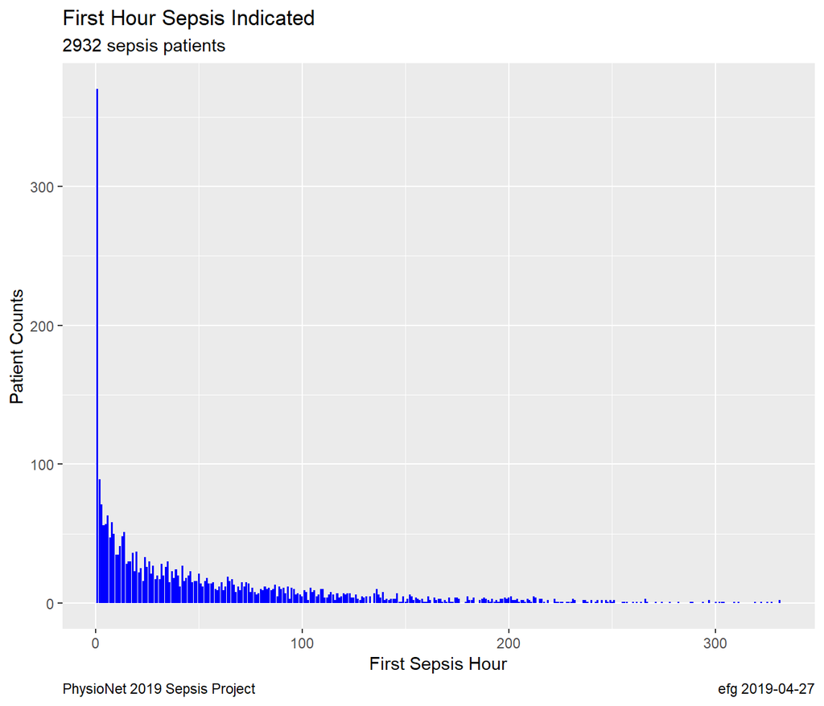

```r
firstSepsisHourCounts     %>%
  ggplot(aes(x = FirstSepsisHour, y = Total))                    +
    geom_bar(stat = "identity", fill="blue")                     +
    labs(title = "First Hour Sepsis Indicated",
         subtitle = paste(sum(firstSepsisHourCounts$Total), "sepsis patients"),
         x = "First Sepsis Hour",
         y = "Patient Counts",
         caption = c(plotCaptionLeft, plotCaptionRight))         +
    theme(plot.caption = element_text(hjust=c(0.0,1.0)))
```

```r
firstSepsisHourCounts <-
  patientSummary                     %>%
  filter(Sepsis == "Sepsis")         %>%
  group_by(FirstSepsisHour, Source)  %>%
  count()                            %>%
  ungroup()
```

```r
sourceCounts   <- table(firstSepsisHourCounts$Source, useNA="ifany")
sourceFacetName <- paste0("Source ", names(sourceCounts), " [", sourceCounts, "]")

sourceLabeller <- function(variable, value)
{
  return(sourceFacetName[value])
}
```

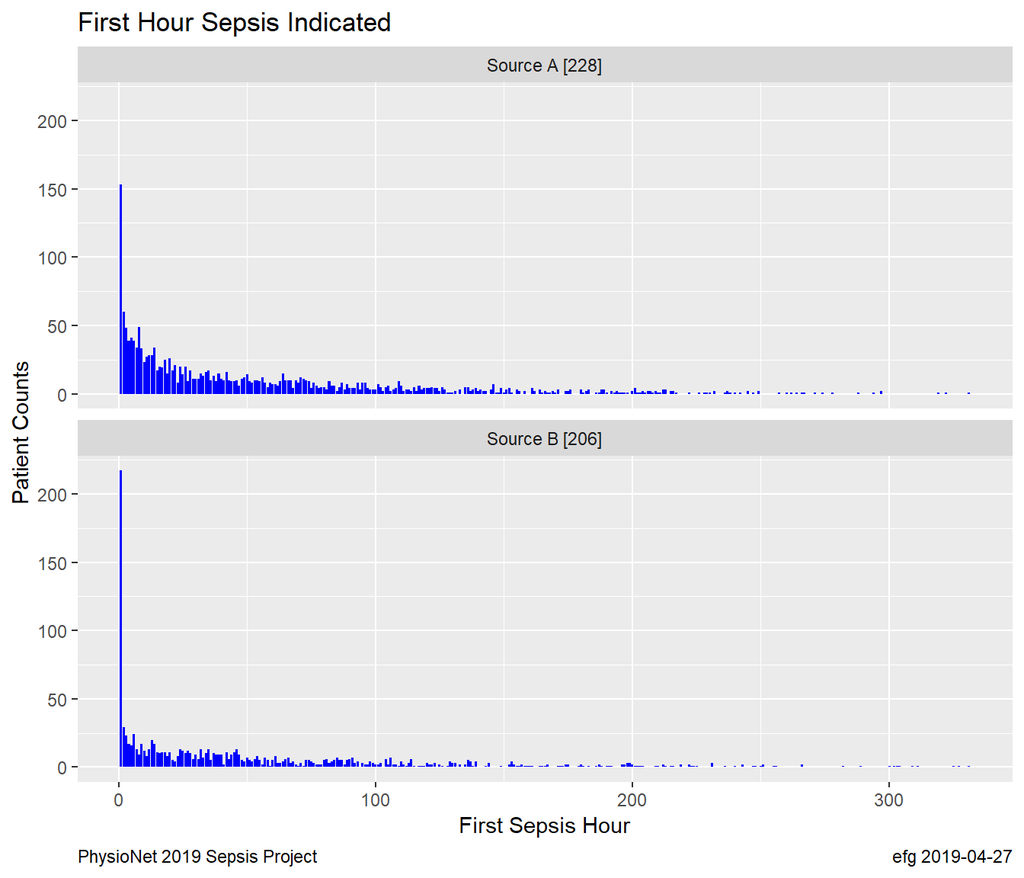

```r
firstSepsisHourCounts     %>%
  ggplot(aes(x = FirstSepsisHour, y = n))                        +
    geom_bar(stat = "identity", fill="blue")                     +
    labs(title = "First Hour Sepsis Indicated",
         x = "First Sepsis Hour",
         y = "Patient Counts",
         caption = c(plotCaptionLeft, plotCaptionRight))         +
    theme(plot.caption = element_text(hjust=c(0.0,1.0)))         +
   facet_wrap(~Source, nrow=2, labeller = as_labeller(sourceLabeller))
```

```r
firstSepsisHourCounts  %>%
  head(10)             %>%
  Show()
```

| FirstSepsisHour | Source | n |
| --- | --- | --- |
| 1 | A | 153 |
| 1 | B | 217 |
| 2 | A | 60 |
| 2 | B | 29 |
| 3 | A | 48 |
| 3 | B | 23 |
| 4 | A | 39 |
| 4 | B | 17 |
| 5 | A | 41 |
| 5 | B | 16 |

### 3.2.4 Sepsis Time Span

How many hours from first to last sepsis record for a sepsis patient?

```r
sepsisSpanHours <-
  patientSummary              %>%
  filter(Sepsis == "Sepsis")  %>%
  group_by(Duration)          %>%
  count()                     %>%
  ungroup()

nrow(sepsisSpanHours)
```

```
[1] 8
```

```r
Show(sepsisSpanHours)
```

| Duration | n |
| --- | --- |
| 1 | 5 |
| 2 | 3 |
| 4 | 2 |
| 6 | 5 |
| 7 | 4 |
| 8 | 248 |
| 9 | 795 |
| 10 | 1870 |

### 3.2.5 Sepsis Time Span for Patients with Sepsis Indicated First Hour

```r
patientSummary                  %>%
  filter(Sepsis == "Sepsis",
         FirstSepsisHour == 1)  %>%
  group_by(Duration)            %>%
  count()                       %>%
  ungroup()                     %>%
  Show()
```

| Duration | n |
| --- | --- |
| 8 | 218 |
| 9 | 106 |
| 10 | 46 |

Does LastSepsisHour always match maxICULOS?

```r
patientSummary                         %>%
  filter(Sepsis == "Sepsis",
         maxICULOS == LastSepsisHour)  %>%
  count()                              %>%
  Show()
```

| n |
| --- |
| 2932 |

Yes!

### 3.2.6 Example Sepsis patients with FirstSepsisHour = 1

```r
firstSepsisHour <-
  patientSummary              %>%
  filter(Sepsis == "Sepsis",
         FirstSepsisHour == 1)

nrow(firstSepsisHour)
```

```
[1] 370
```

```r
firstSepsisHour  %>%
  head(3)        %>%
  Show()
```

| Source | patient | nRecord | Age | Gender | Unit1 | Unit2 | HospAdmTime | minICULOS | maxICULOS | gapICULOS | Sepsis | SepsisHours | FirstSepsisHour | LastSepsisHour | Duration |
| --- | --- | --- | --- | --- | --- | --- | --- | --- | --- | --- | --- | --- | --- | --- | --- |
| A | p000056 | 9 | 68.20 | Male | 1 | 0 | -140.06 | 1 | 9 | 1 | Sepsis | 9 | 1 | 9 | 9 |
| A | p000058 | 8 | 46.02 | Male | 1 | 0 | -244.37 | 1 | 8 | 1 | Sepsis | 8 | 1 | 8 | 8 |
| A | p000260 | 9 | 87.46 | Female | 0 | 1 | -509.42 | 1 | 9 | 1 | Sepsis | 9 | 1 | 9 | 9 |

#### 3.2.6.1 68 year old male

```r
example1 <-
  allData                      %>%
  filter(patient == "p000056")
nrow(example1)
```

```
[1] 9
```

```r
example1 %>% Show()
```

| Source | patient | ICULOS | HR | O2Sat | Temp | SBP | MAP | DBP | Resp | EtCO2 | BaseExcess | HCO3 | FiO2 | pH | PaCO2 | SaO2 | AST | BUN | Alkalinephos | Calcium | Chloride | Creatinine | Bilirubin_direct | Glucose | Lactate | Magnesium | Phosphate | Potassium | Bilirubin_total | … |
| --- | --- | --- | --- | --- | --- | --- | --- | --- | --- | --- | --- | --- | --- | --- | --- | --- | --- | --- | --- | --- | --- | --- | --- | --- | --- | --- | --- | --- | --- | --- |
| A | p000056 | 1 | NA | NA | NA | NA | NA | NA | NA | NA | NA | NA | NA | NA | NA | NA | NA | NA | NA | NA | NA | NA | NA | NA | NA | NA | NA | NA | NA | … |
| A | p000056 | 2 | 86 | 100.0 | 36.39 | 118 | 73 | 57 | 17.0 | NA | NA | NA | NA | NA | NA | NA | NA | NA | NA | NA | NA | NA | NA | NA | NA | NA | NA | NA | NA | … |
| A | p000056 | 3 | 86 | 97.0 | 36.89 | 116 | 75 | 59 | 16.0 | NA | NA | NA | NA | NA | NA | NA | NA | NA | NA | NA | NA | NA | NA | NA | NA | NA | NA | NA | NA | … |
| A | p000056 | 4 | 84 | 96.5 | 36.56 | 141 | 87 | 66 | 15.5 | NA | NA | NA | NA | NA | NA | NA | NA | NA | NA | NA | NA | NA | NA | NA | NA | NA | NA | NA | NA | … |
| A | p000056 | 5 | 85 | 97.0 | NA | 147 | 90 | 66 | 14.0 | NA | NA | NA | NA | NA | NA | NA | NA | NA | NA | NA | NA | NA | NA | NA | NA | NA | NA | NA | NA | … |
| A | p000056 | 6 | 91 | 97.0 | NA | 144 | 95 | 70 | 19.0 | NA | NA | NA | NA | NA | NA | NA | NA | NA | NA | NA | NA | NA | NA | NA | NA | NA | NA | NA | NA | … |
| A | p000056 | 7 | 93 | 94.0 | NA | 139 | 90 | 66 | 16.0 | NA | NA | 21 | 0.5 | NA | NA | NA | NA | 107 | NA | 7.5 | 95 | 10.6 | NA | 141 | NA | 1.8 | 8.2 | 4.3 | NA | … |
| A | p000056 | 8 | 94 | 91.0 | 36.89 | 140 | 88 | 64 | 15.0 | NA | NA | NA | NA | NA | NA | NA | NA | NA | NA | NA | NA | NA | NA | NA | NA | NA | NA | NA | NA | … |
| A | p000056 | 9 | 93 | 97.0 | NA | 130 | 79 | 55 | 15.0 | NA | NA | NA | 0.5 | NA | NA | NA | NA | NA | NA | NA | NA | NA | NA | NA | NA | NA | NA | NA | NA | … |

#### 3.2.6.2 87 year old female

```r
allData                         %>%
  filter(patient == "p000260")  %>%
  Show()
```

| Source | patient | ICULOS | HR | O2Sat | Temp | SBP | MAP | DBP | Resp | EtCO2 | BaseExcess | HCO3 | FiO2 | pH | PaCO2 | SaO2 | AST | BUN | Alkalinephos | Calcium | Chloride | Creatinine | Bilirubin_direct | Glucose | Lactate | Magnesium | Phosphate | Potassium | Bilirubin_total | … |
| --- | --- | --- | --- | --- | --- | --- | --- | --- | --- | --- | --- | --- | --- | --- | --- | --- | --- | --- | --- | --- | --- | --- | --- | --- | --- | --- | --- | --- | --- | --- |
| A | p000260 | 1 | NA | NA | NA | NA | NA | NA | NA | NA | NA | NA | NA | NA | NA | NA | NA | NA | NA | NA | NA | NA | NA | NA | NA | NA | NA | NA | NA | … |
| A | p000260 | 2 | 108 | 100.0 | 35.28 | 92.0 | 68.0 | 50.0 | 21 | NA | -5 | NA | 0.6 | 7.19 | 61 | 97 | NA | NA | NA | NA | NA | NA | NA | 148 | 1.4 | NA | NA | NA | NA | … |
| A | p000260 | 3 | 93 | 98.0 | 35.61 | 102.0 | 70.5 | 48.0 | 24 | NA | -3 | NA | NA | 7.30 | 47 | NA | NA | NA | NA | NA | NA | NA | NA | NA | NA | NA | NA | NA | NA | … |
| A | p000260 | 4 | 96 | 99.0 | NA | 100.0 | 67.0 | 47.0 | 24 | NA | NA | NA | NA | NA | NA | NA | NA | NA | NA | NA | NA | NA | NA | NA | NA | NA | NA | NA | NA | … |
| A | p000260 | 5 | NA | NA | NA | NA | NA | NA | NA | NA | NA | NA | NA | NA | NA | NA | NA | NA | NA | NA | NA | NA | NA | NA | NA | NA | NA | NA | NA | … |
| A | p000260 | 6 | 80 | 97.5 | NA | 113.5 | 75.5 | 51.5 | 24 | NA | NA | NA | 0.6 | NA | NA | NA | NA | NA | NA | NA | NA | NA | NA | NA | NA | NA | NA | NA | NA | … |
| A | p000260 | 7 | 71 | 100.0 | 36.33 | 115.0 | 75.0 | 50.0 | 24 | NA | -2 | NA | NA | 7.42 | 32 | NA | NA | NA | NA | NA | NA | NA | NA | NA | NA | NA | NA | NA | NA | … |
| A | p000260 | 8 | 78 | 100.0 | NA | 117.0 | 67.0 | 51.0 | 24 | NA | NA | NA | NA | NA | NA | NA | NA | NA | NA | NA | NA | NA | NA | NA | NA | NA | NA | NA | NA | … |
| A | p000260 | 9 | 88 | 100.0 | NA | 102.0 | 58.0 | 48.0 | 24 | NA | NA | 23 | NA | NA | NA | NA | 78 | 55 | 105 | 8.2 | 109 | 0.9 | NA | 116 | NA | 2 | 3.7 | 4.7 | 5.3 | … |

## 3.3 Raw Records Per Patient

There is one record per hour, but the first patient record is sometimes not hour 1.

### 3.3.1 All Patients

The median number of records per patient is 38.

```r
quantile(patientSummary$nRecord,
         c(0.0, 0.01, 0.10, 0.25, 0.50, 0.75, 0.90, 0.99, 1.00))
```

```
  0%   1%  10%  25%  50%  75%  90%  99% 100%
   8    9   18   24   38   47   55  133  336
```

```r
recordsPerPatient <-
  patientSummary       %>%
  group_by(nRecord)    %>%
  count()              %>%
  ungroup()
```

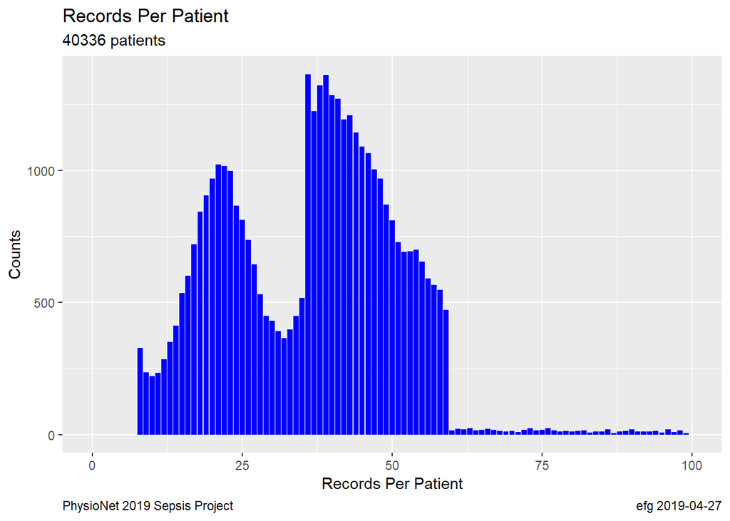

```r
recordsPerPatient                                               %>%
  ggplot(aes(x = nRecord, y = n))                                +
    geom_bar(stat = "identity", fill="blue")                     +
  # scale_x_log10(breaks = LOSbreaks)                            +
    xlim(0, 100)                                                 +
    labs(title = "Records Per Patient",
         subtitle = paste(sum(recordsPerPatient$n), "patients"),
         x = "Records Per Patient",
         y = "Counts",
         caption = c(plotCaptionLeft, plotCaptionRight))         +
    theme(plot.caption = element_text(hjust=c(0.0,1.0)))
```

### 3.3.2 Sepsis Patients

```r
recordsPerSepsisPatient <-
  patientSummary              %>%
  filter(Sepsis == "Sepsis")  %>%
  group_by(nRecord)           %>%
  count()                     %>%
  ungroup()
```

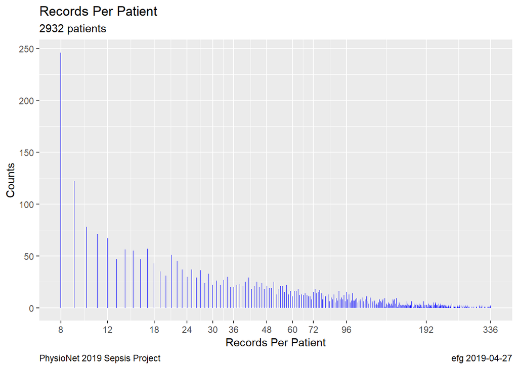

```r
recordsPerSepsisPatient                                         %>%
  ggplot(aes(x = nRecord, y = n))                                +
    geom_bar(stat = "identity", fill="blue")                     +
    scale_x_log10(breaks = LOSbreaks)                            +
    labs(title = "Records Per Patient",
         subtitle = paste(sum(recordsPerSepsisPatient$n), "patients"),
         x = "Records Per Patient",
         y = "Counts",
         caption = c(plotCaptionLeft, plotCaptionRight))         +
    theme(plot.caption = element_text(hjust=c(0.0,1.0)))
```

## 3.4 Age

### 3.4.1 All Patients

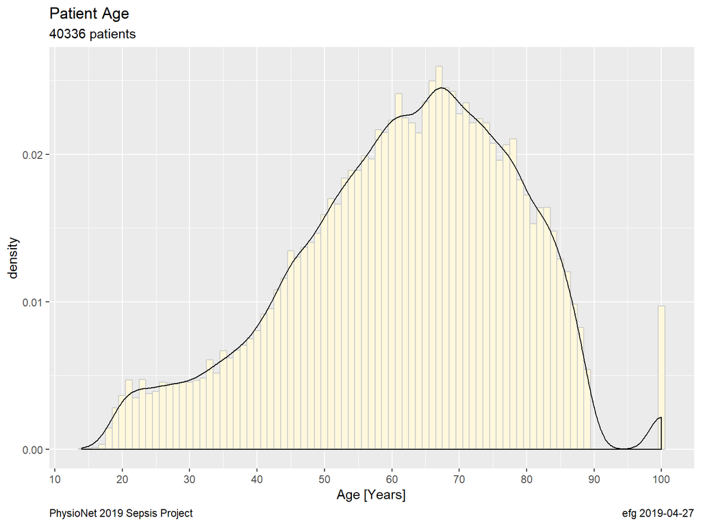

```r
patientSummary                                                 %>%
  ggplot(aes(x = Age, y = ..density..))                         +
    geom_histogram(fill="cornsilk", color="grey80", binwidth=1) +
    geom_density()                                              +
    scale_x_continuous(breaks = 10 * 1:10)                      +
    labs(title    = "Patient Age",
         subtitle = paste(nrow(patientSummary), "patients"),
         x = "Age [Years]",
         caption = c(plotCaptionLeft, plotCaptionRight))        +
    theme(plot.caption = element_text(hjust=c(0.0,1.0)))
```

### 3.4.2 By Sepsis Status

```r
sepsisCounts   <- table(patientSummary$Sepsis, useNA="ifany")
sepsisFacetName <- paste0(names(sepsisCounts), "[", sepsisCounts, "]")

sepsisLabeller <- function(variable, value)
{
  return(sepsisFacetName[value])
}
```

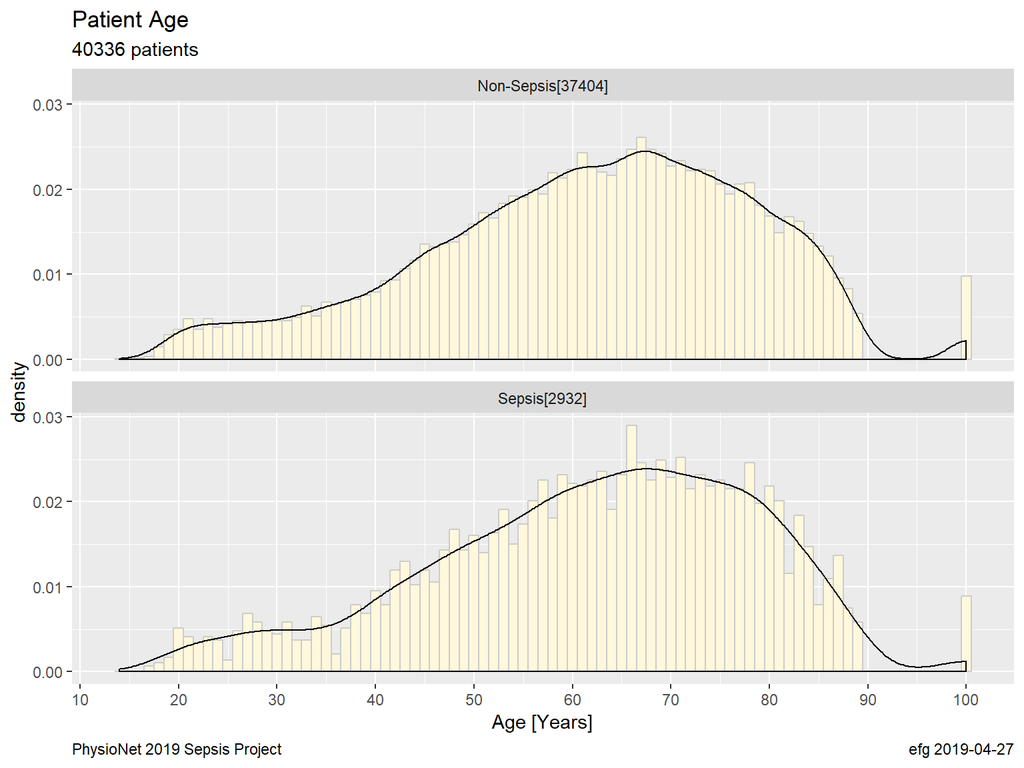

```r
patientSummary                                                 %>%
  ggplot(aes(x = Age, y = ..density..))                         +
    geom_histogram(fill="cornsilk", color="grey80", binwidth=1) +
    geom_density()                                              +
    scale_x_continuous(breaks = 10 * 1:10)                      +
    labs(title    = "Patient Age",
         subtitle = paste(nrow(patientSummary), "patients"),
         x = "Age [Years]",
         caption = c(plotCaptionLeft, plotCaptionRight))        +
    theme(plot.caption = element_text(hjust=c(0.0,1.0)))        +
    facet_wrap(~Sepsis, nrow=2, labeller = as_labeller(sepsisLabeller))
```

### 3.4.3 By Gender

```r
genderCounts   <- table(patientSummary$Gender, useNA="ifany")
genderFacetName <- paste0(names(genderCounts), "[", genderCounts, "]")

genderLabeller <- function(variable, value)
{
  return(genderFacetName[value])
}
```

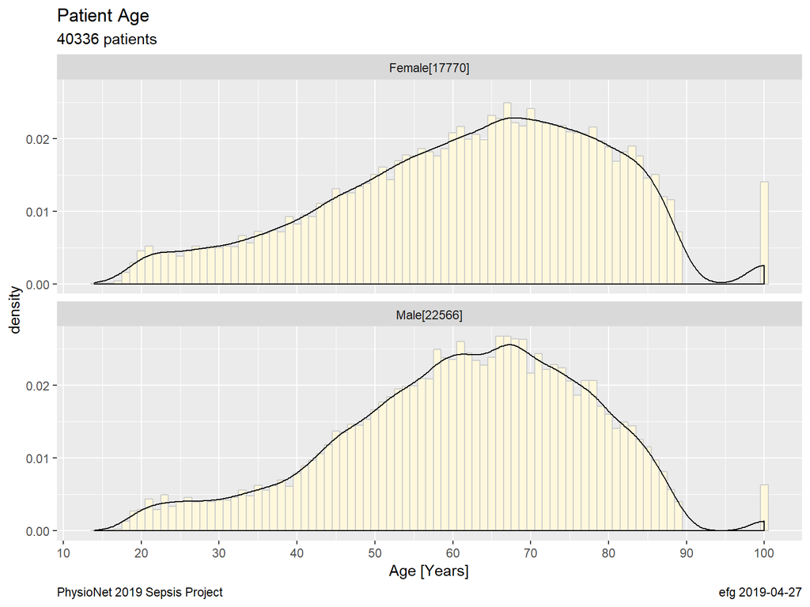

```r
patientSummary                                                 %>%
  ggplot(aes(x = Age, y = ..density..))                         +
    geom_histogram(fill="cornsilk", color="grey80", binwidth=1) +
    geom_density()                                              +
    scale_x_continuous(breaks = 10 * 1:10)                      +
    labs(title    = "Patient Age",
         subtitle = paste(nrow(patientSummary), "patients"),
         x = "Age [Years]",
         caption = c(plotCaptionLeft, plotCaptionRight))        +
    theme(plot.caption = element_text(hjust=c(0.0,1.0)))        +
    facet_wrap(~Gender, nrow=2, labeller = as_labeller(genderLabeller))
```

## 3.5 Gender

```r
table(patientSummary$Gender, useNA = "ifany")
```

```
Female   Male
 17770  22566
```

```r
table(patientSummary$Sepsis, patientSummary$Gender, useNA = "ifany")
```

```
             Female  Male
  Non-Sepsis  16577 20827
  Sepsis       1193  1739
```

## 3.6 Units

Not sure how to use this information

### 3.6.1 Unit 1

```r
table(patientSummary$Unit1, useNA = "ifany")
```

```
    0     1  <NA>
12452 12267 15617
```

### 3.6.2 Unit 2

```r
table(patientSummary$Unit2, useNA = "ifany")
```

```
    0     1  <NA>
12267 12452 15617
```

### 3.6.3 Unit 1 and 2 are mutually exclusive when known

```r
table(patientSummary$Unit1, patientSummary$Unit2, useNA = "ifany")
```

```
           0     1  <NA>
  0        0 12452     0
  1    12267     0     0
  <NA>     0     0 15617
```

## 3.7 Hospital Admit Time

Hours between hospital admit and ICU admit

#### 3.7.0.1 All Patients

Some large negative values

```r
quantile(patientSummary$HospAdmTime,
         c(0.0, 0.01, 0.05, 0.10, 0.25, 0.50, 0.75, 0.90, 0.95, 0.99, 1.00), na.rm = TRUE)
```

```
        0%         1%         5%        10%        25%        50%
-5366.8600  -602.8742  -240.9420  -147.0780   -43.6850    -6.0500
       75%        90%        95%        99%       100%
   -0.0400    -0.0200    -0.0100     0.0000    23.9900
```

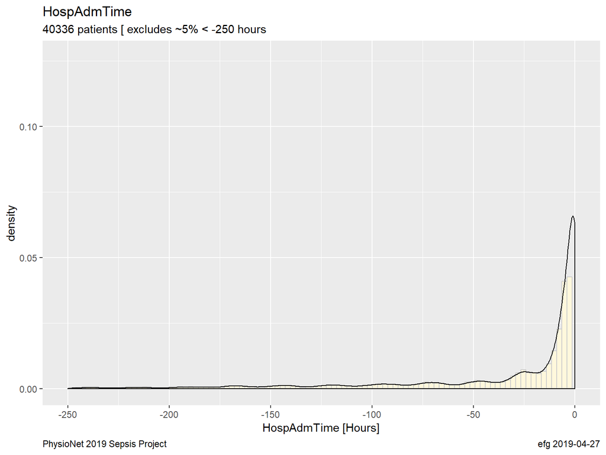

```r
patientSummary                                                  %>%
  ggplot(aes(x = HospAdmTime, y = ..density..))                  +
    geom_histogram(fill="cornsilk", color="grey80", bins=100)    +
    geom_density()                                               +
    xlim(-250, 0)                                                +
    labs(title    = "HospAdmTime",
         subtitle = paste(nrow(patientSummary), "patients [",
                          "excludes ~5% < -250 hours"),
         x = "HospAdmTime [Hours]",
         caption = c(plotCaptionLeft, plotCaptionRight))         +
    theme(plot.caption = element_text(hjust=c(0.0,1.0)))
```

#### 3.7.0.2 By Sepsis Status

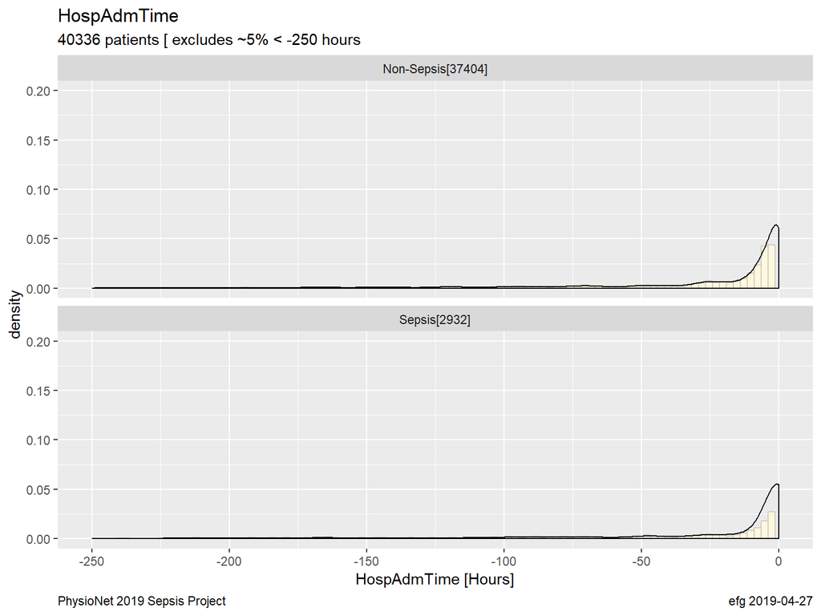

```r
patientSummary                                                  %>%
  ggplot(aes(x = HospAdmTime, y = ..density..))                  +
    geom_histogram(fill="cornsilk", color="grey80", bins=100)    +
    geom_density()                                               +
    xlim(-250, 0)                                                +
    labs(title    = "HospAdmTime",
         subtitle = paste(nrow(patientSummary), "patients [",
                          "excludes ~5% < -250 hours"),
         x = "HospAdmTime [Hours]",
         caption = c(plotCaptionLeft, plotCaptionRight))         +
    theme(plot.caption = element_text(hjust=c(0.0,1.0)))         +
    facet_wrap(~Sepsis, nrow=2, labeller = as_labeller(sepsisLabeller))
```

## 3.8 ICU length-of-stay

### 3.8.1 Always starts at hour 1?

```r
table(patientSummary$minICULOS, useNA = "ifany")
```

```
    1     2     3     4     5     6     7     8     9    10    11    12
31543  4129  1897  1149   653   423   233   123    67    32    19    14
   13    14    15    16    17    18    19    20    21    23    24    25
    5     9     5     4     4     3     2     1     1     4     1     2
   26    27    28    30   269   282   304
    3     2     1     4     1     1     1
```

That’s not the case. Examples:

```r
patientSummary           %>%
  filter(minICULOS > 8)  %>%
  Show()                 %>%
  scroll_box(height = "400px")
```

| Source | patient | nRecord | Age | Gender | Unit1 | Unit2 | HospAdmTime | minICULOS | maxICULOS | gapICULOS | Sepsis | SepsisHours | FirstSepsisHour | LastSepsisHour | Duration |
| --- | --- | --- | --- | --- | --- | --- | --- | --- | --- | --- | --- | --- | --- | --- | --- |
| A | p000061 | 18 | 75.79 | Male | 0 | 1 | -27.03 | 30 | 47 | 1 | Non-Sepsis | 0 | NA | NA | NA |
| A | p000297 | 9 | 43.47 | Male | 1 | 0 | -0.06 | 11 | 19 | 1 | Non-Sepsis | 0 | NA | NA | NA |
| A | p000375 | 37 | 56.21 | Male | NA | NA | -0.02 | 13 | 49 | 1 | Non-Sepsis | 0 | NA | NA | NA |
| A | p000672 | 12 | 76.97 | Male | NA | NA | -0.05 | 16 | 27 | 1 | Non-Sepsis | 0 | NA | NA | NA |
| A | p000822 | 30 | 59.15 | Male | NA | NA | -5.47 | 12 | 41 | 1 | Non-Sepsis | 0 | NA | NA | NA |
| A | p000832 | 33 | 63.79 | Male | 0 | 1 | -16.18 | 9 | 41 | 1 | Non-Sepsis | 0 | NA | NA | NA |
| A | p000995 | 29 | 51.66 | Male | NA | NA | -1.14 | 9 | 37 | 1 | Non-Sepsis | 0 | NA | NA | NA |
| A | p001146 | 24 | 63.85 | Male | 1 | 0 | 0.00 | 9 | 32 | 1 | Non-Sepsis | 0 | NA | NA | NA |
| A | p001148 | 22 | 45.70 | Male | 0 | 1 | -22.30 | 15 | 36 | 1 | Non-Sepsis | 0 | NA | NA | NA |
| A | p001365 | 29 | 43.49 | Female | NA | NA | -1510.72 | 12 | 40 | 1 | Non-Sepsis | 0 | NA | NA | NA |
| A | p001682 | 8 | 80.29 | Male | 0 | 1 | -109.48 | 9 | 16 | 1 | Non-Sepsis | 0 | NA | NA | NA |
| A | p001702 | 49 | 22.80 | Male | NA | NA | -0.03 | 10 | 58 | 1 | Non-Sepsis | 0 | NA | NA | NA |
| A | p001744 | 123 | 65.75 | Male | NA | NA | -96.90 | 10 | 132 | 1 | Sepsis | 10 | 123 | 132 | 10 |
| A | p002200 | 29 | 82.51 | Male | 0 | 1 | -1389.93 | 16 | 44 | 1 | Non-Sepsis | 0 | NA | NA | NA |
| A | p002233 | 26 | 50.02 | Female | 0 | 1 | -14.27 | 9 | 34 | 1 | Non-Sepsis | 0 | NA | NA | NA |
| A | p002546 | 54 | 58.64 | Female | NA | NA | -0.05 | 12 | 65 | 1 | Sepsis | 10 | 56 | 65 | 10 |
| A | p002609 | 47 | 42.93 | Female | 0 | 1 | 0.00 | 10 | 56 | 1 | Non-Sepsis | 0 | NA | NA | NA |
| A | p003171 | 41 | 56.63 | Male | NA | NA | -0.02 | 9 | 49 | 1 | Non-Sepsis | 0 | NA | NA | NA |
| A | p003576 | 31 | 42.71 | Male | 1 | 0 | -0.03 | 14 | 44 | 1 | Non-Sepsis | 0 | NA | NA | NA |
| A | p003840 | 30 | 71.99 | Female | 0 | 1 | -446.03 | 12 | 41 | 1 | Non-Sepsis | 0 | NA | NA | NA |
| A | p003866 | 35 | 25.72 | Male | NA | NA | -0.02 | 10 | 44 | 1 | Sepsis | 10 | 35 | 44 | 10 |
| A | p004004 | 33 | 51.66 | Male | 0 | 1 | -17.33 | 9 | 41 | 1 | Non-Sepsis | 0 | NA | NA | NA |
| A | p004208 | 40 | 63.33 | Male | 0 | 1 | -16.74 | 9 | 48 | 1 | Non-Sepsis | 0 | NA | NA | NA |
| A | p004247 | 27 | 82.17 | Female | NA | NA | -0.02 | 14 | 40 | 1 | Non-Sepsis | 0 | NA | NA | NA |
| A | p004494 | 34 | 59.70 | Male | 0 | 1 | -86.64 | 11 | 44 | 1 | Non-Sepsis | 0 | NA | NA | NA |
| A | p004976 | 13 | 63.30 | Female | 1 | 0 | -362.48 | 25 | 37 | 1 | Non-Sepsis | 0 | NA | NA | NA |
| A | p005144 | 46 | 40.18 | Female | 0 | 1 | -0.03 | 10 | 55 | 1 | Non-Sepsis | 0 | NA | NA | NA |
| A | p005419 | 16 | 82.11 | Female | 1 | 0 | 0.00 | 12 | 27 | 1 | Non-Sepsis | 0 | NA | NA | NA |
| A | p005518 | 36 | 46.46 | Male | NA | NA | -4.64 | 9 | 44 | 1 | Non-Sepsis | 0 | NA | NA | NA |
| A | p005609 | 28 | 66.70 | Male | NA | NA | -19.16 | 17 | 44 | 1 | Non-Sepsis | 0 | NA | NA | NA |

[output cut: 156 more lines]

Verified p01195 started at hour 9 and continued through hour 51.

### 3.8.2 Hourly gap(s) after first reported hour?

```r
table(patientSummary$gapICULOS, useNA = "ifany")
```

```
    1
40336
```

No gaps!

### 3.8.3 ICULOS All Patients

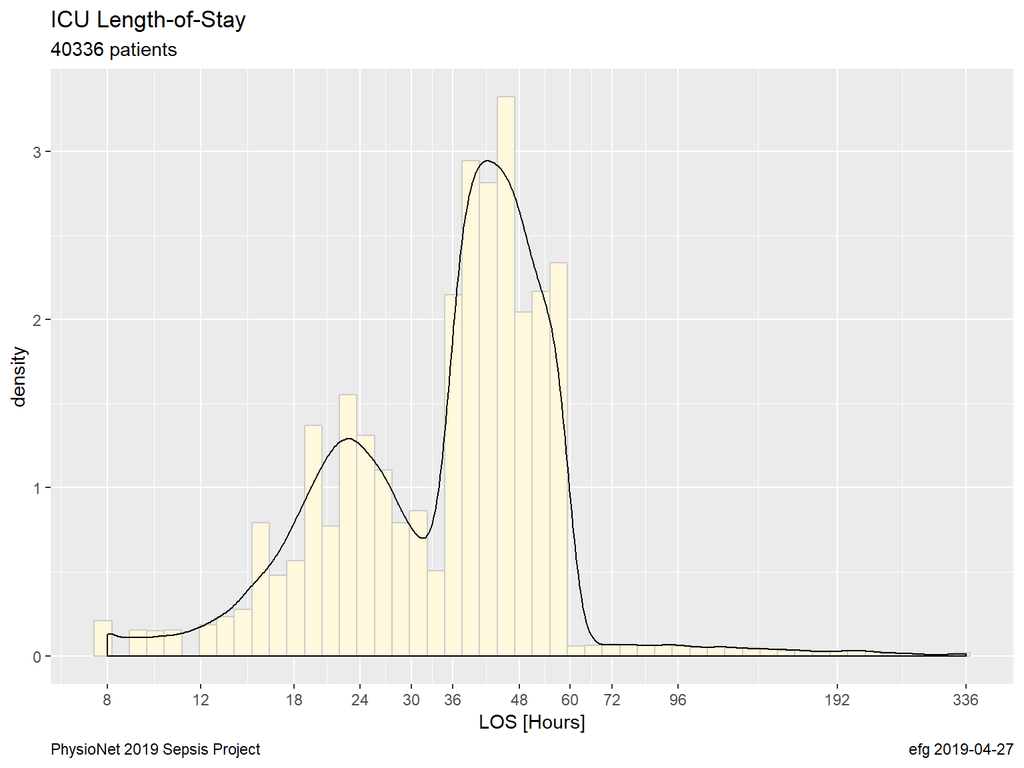

```r
patientSummary                                                  %>%
  ggplot(aes(x = maxICULOS, y = ..density..))                    +
    geom_histogram(fill="cornsilk", color="grey80", bins=50)     +
    geom_density()                                               +
    scale_x_log10(breaks = LOSbreaks)                            +
    labs(title    = "ICU Length-of-Stay",
         subtitle = paste(nrow(patientSummary), "patients"),
         x = "LOS [Hours]",
         caption = c(plotCaptionLeft, plotCaptionRight))         +
    theme(plot.caption = element_text(hjust=c(0.0,1.0)))
```

Bimodal peaks always beg for an interpretation!

### 3.8.4 ICULOS By Sepsis Status

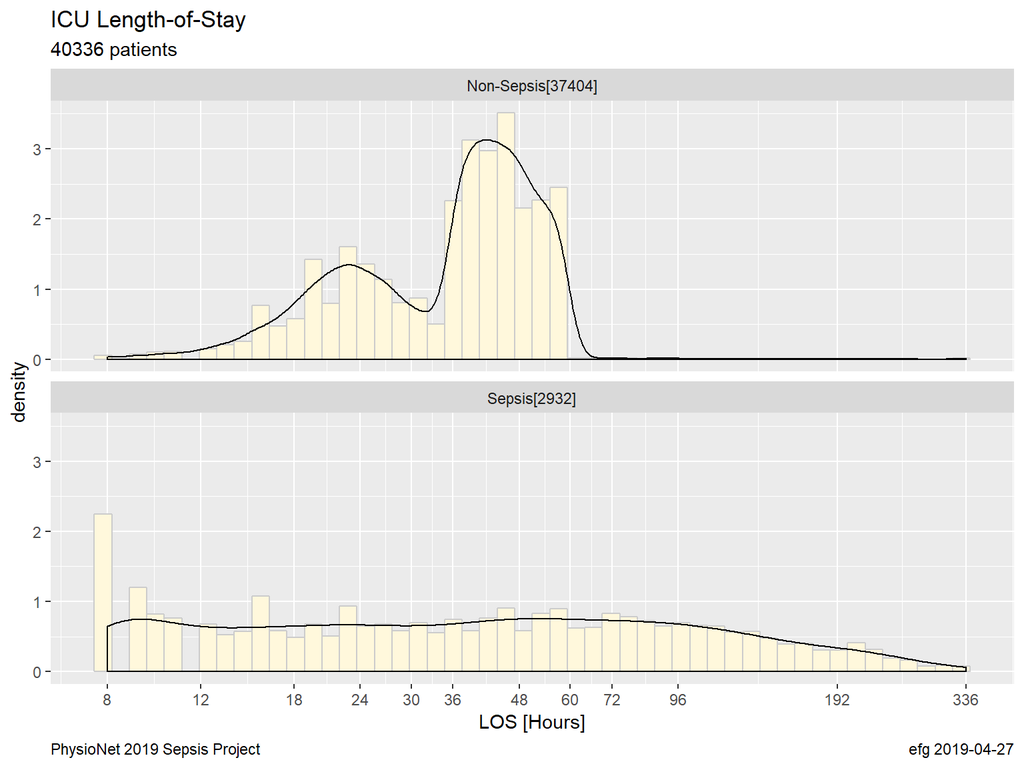

```r
patientSummary                                                  %>%
  ggplot(aes(x = maxICULOS, y = ..density..))                    +
    geom_histogram(fill="cornsilk", color="grey80", bins=50)     +
    geom_density()                                               +
    scale_x_log10(breaks = LOSbreaks)                            +
    labs(title    = "ICU Length-of-Stay",
         subtitle = paste(nrow(patientSummary), "patients"),
         x = "LOS [Hours]",
         caption = c(plotCaptionLeft, plotCaptionRight))         +
    theme(plot.caption = element_text(hjust=c(0.0,1.0)))         +
    facet_wrap(~Sepsis, nrow=2, labeller = as_labeller(sepsisLabeller))
```

Two modes not seen in sepsis patients.

## 3.9 ICU Hours Recorded

Nearly the same as number of records per patient.

```r
byHour <-
  allData                  %>%
  filter(SepsisLabel == 1) %>%
  group_by(ICULOS)         %>%
  count()                  %>%
  ungroup()
```

[figure not shown]

```r
byHour                                                          %>%
  ggplot(aes(x = ICULOS, y = n))                                 +
    geom_bar(stat = "identity", fill="blue")                     +
    #geom_density()                                              +
   # scale_x_log10(breaks = LOSbreaks)                            +
    labs(title    = "ICULOS Hours (All Patients, All Hours)",
         subtitle = paste(nrow(allData), "records"),
         x = "ICULOS [Hour]",
         y = "Counts",
         caption = c(plotCaptionLeft, plotCaptionRight))         +
    theme(plot.caption = element_text(hjust=c(0.0,1.0)))
```

### 3.9.2 Sepsis Patients, All Hours

```r
byHourSepsisPatient <-
  patientSummary              %>%
  filter(Sepsis == "Sepsis")  %>%
  select(patient)             %>%
  inner_join(allData, by = "patient")  %>%
  group_by(ICULOS)            %>%
  count()                     %>%
  ungroup()

nrow(byHourSepsisPatient)
```

```
[1] 336
```

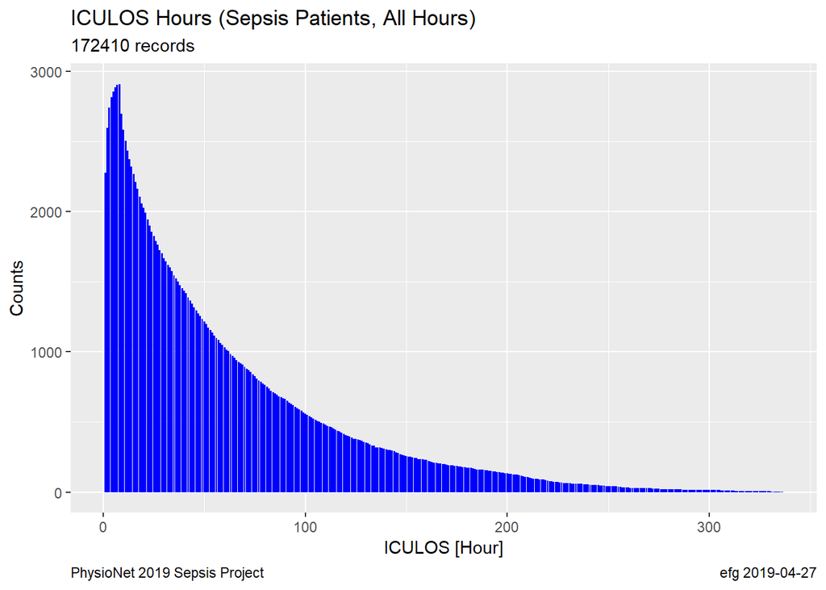

```r
byHourSepsisPatient                                             %>%
  ggplot(aes(x = ICULOS, y = n))                                 +
    geom_bar(stat = "identity", fill="blue")                     +
    #geom_density()                                              +
    #scale_x_log10(breaks = LOSbreaks)                            +
    labs(title    = "ICULOS Hours (Sepsis Patients, All Hours)",
         subtitle = paste(sum(byHourSepsisPatient$n), "records"),
         x = "ICULOS [Hour]",
         y = "Counts",
         caption = c(plotCaptionLeft, plotCaptionRight))         +
    theme(plot.caption = element_text(hjust=c(0.0,1.0)))
```

### 3.9.3 Sepsis Patients, Sepsis Hours

```r
byHourSepsisPatient <-
  allData                     %>%
  filter(SepsisLabel == 1)    %>%
  group_by(ICULOS)            %>%
  count()                     %>%
  ungroup()

nrow(byHourSepsisPatient)
```

```
[1] 336
```

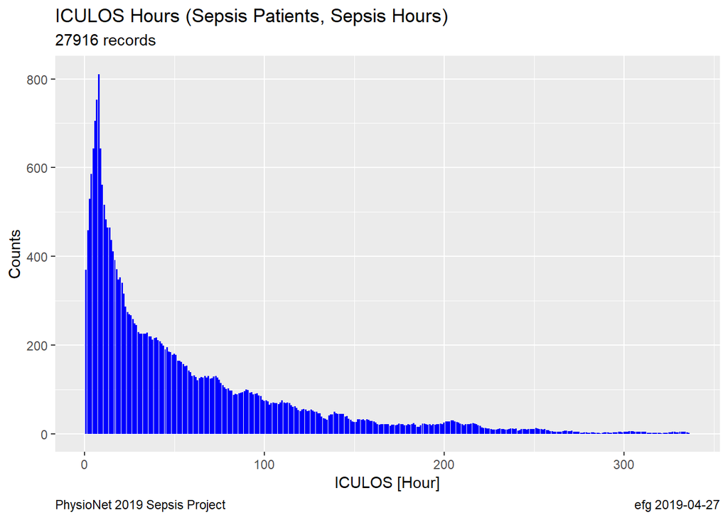

```r
byHourSepsisPatient                                             %>%
  ggplot(aes(x = ICULOS, y = n))                                 +
    geom_bar(stat = "identity", fill="blue")                     +
#   scale_x_log10(breaks = LOSbreaks)                            +
    labs(title    = "ICULOS Hours (Sepsis Patients, Sepsis Hours)",
         subtitle = paste(sum(byHourSepsisPatient$n), "records"),
         x = "ICULOS [Hour]",
         y = "Counts",
         caption = c(plotCaptionLeft, plotCaptionRight))         +
    theme(plot.caption = element_text(hjust=c(0.0,1.0)))
```

# 4 Discussion

[work in progress]

# 5 Conclusions

[work in progress]

Processing time: 20.2 secs

2019-04-27 2103